# 260-2015-11-16-vision-II

2015-11-17 15:21:17

## Prelude

[video not shown]

## Announcements

- Exam 3 Friday
- Exam review on Wednesday

## Today's topics

- Vision: From eye to brain

## Retinal layers

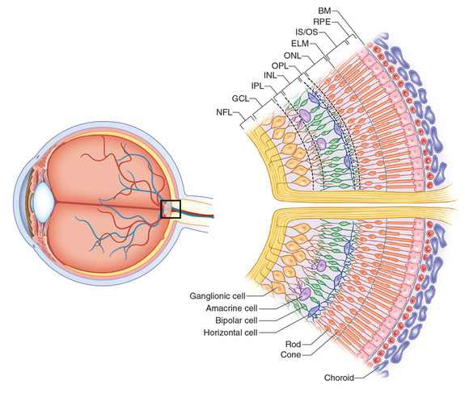

http://www.retinareference.com/anatomy/

## Retinal layers

- Bipolar cells
  - Horizontal cells
- Retinal ganglion cells
  - Amacrine cells

## *Center-surround receptive fields*

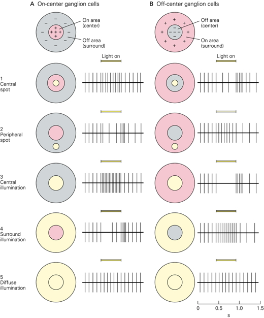

## Center-surround receptive fields

- Center region
  - Excites (or inhibits)
- Surround region
  - Does the opposite
- Bipolar cells & Retinal Ganglion cells ->
- Most activated by "donuts" of light/dark
  - Local contrast (light/dark differences)

## What's a reddish-green look like?

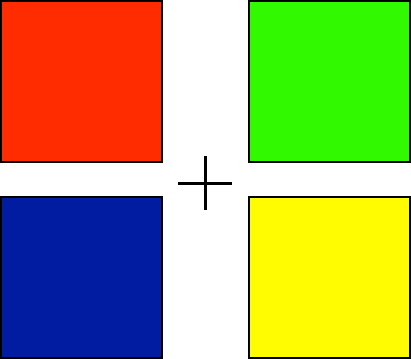

## What's a reddish-green look like?

## *Opponent processing*

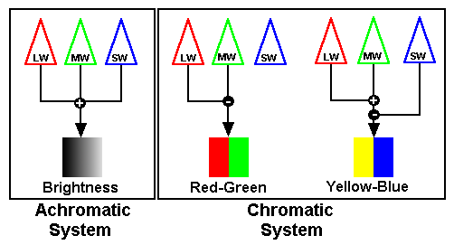

http://www.visualexpert.com/sbfaqimages/RGBOpponent.gif

## Opponent processing

- Black vs. white (achromatic)
- Long (red) vs. Medium (green) wavelength cones
- (Long + Medium) vs. Short cones
- Can't really see reddish-green or bluish-yellow

## From eye to brain

[figure not shown]

## From eye to brain

- Retinal ganglion cells
- 2nd/II cranial (optic) nerve
  - Optic chiasm
- *Lateral Geniculate Nucleus (LGN)* of thalamus (90% of projections)

## From eye to brain

- Hypothalamus
  - Suprachiasmatic n.
- Superior colliculus & brainstem

## LGN

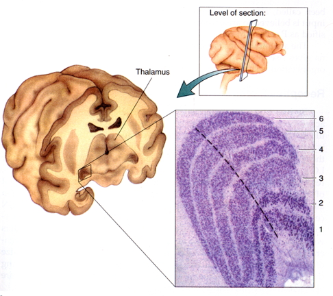

## LGN

- 6 layers + intralaminar zone
  - Parvocellular (small cells): chromatic
  - Magnocellular (big cells): achromatic
  - Koniocellular (chromatic - short wavelength?)
- Retinotopic map of opposite visual field

## From LGN to V1

[figure not shown]

## From LGN to V1

- Via optic radiations
- *[Primary visual cortex (V1)](http://www.scholarpedia.org/article/Area_V1)* in occipital lobe

## Human V1

[figure not shown]

http://www.scholarpedia.org/w/images/3/3a/03-Human-V1.png

## Measuring retinotopy in V1

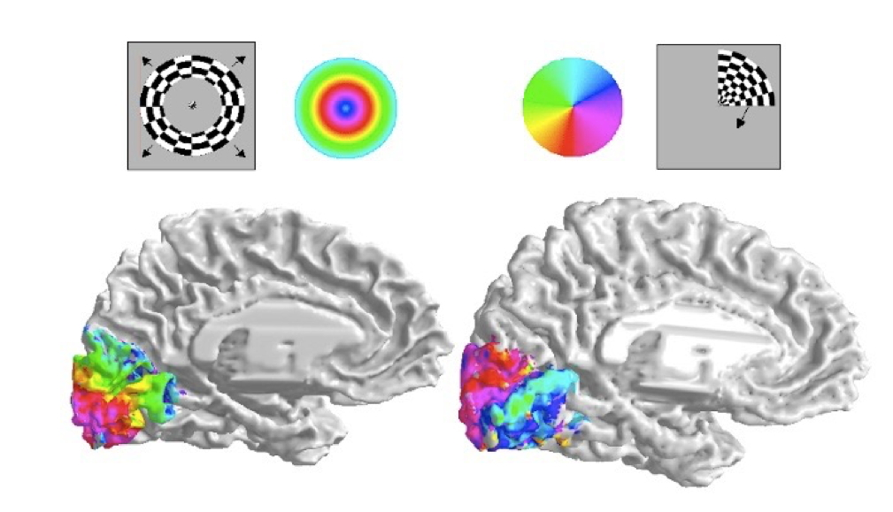

[(Dougherty et al. 2003)](http://dx.doi.org/10.1167/3.10.1)

## Retinotopy in V1

- Fovea overrepresented
  - Analogous to somatosensation
  - High acuity in fovea vs. lower outside it
- Upper visual field/lower (ventral) V1 and *vice versa*

## V1 has laminar, columnar organization

[figure not shown]

## V1 has laminar, columnar organization

- 6 laminae (layers)
  - Input: Layer 4
  - Output: Layers 2-3 (to cortex), 5 (to brainstem), 6 (to LGN)

## V1 has laminar, columnar organization

- Columns
  - Orientation/angle
  - Spatial frequency

## Orientation/angle tuning

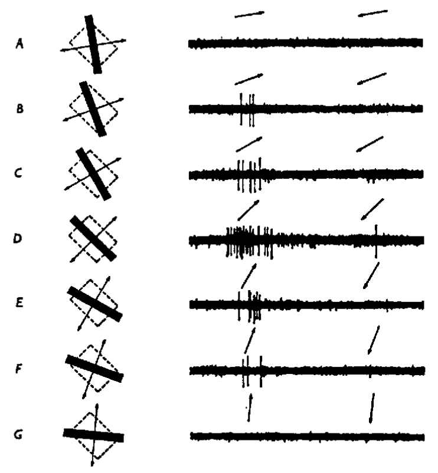

https://foundationsofvision.stanford.edu/wp-content/uploads/2012/02/dir.selective.png

## From center-surround receptive fields to line detection

[figure not shown]

## Spatial frequency tuning

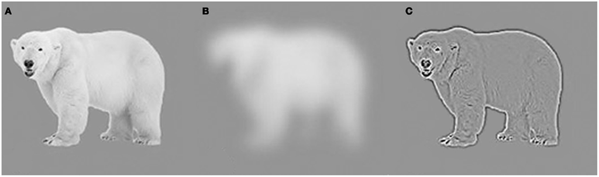

[(Panichello, Cheung, and Bar 2013)](http://dx.doi.org/10.3389/fpsyg.2012.00620)

## V1 has laminar, columnar organization

- Columns
  - Color/wavelength
  - Eye of origin, *ocular dominance*

## Ocular dominance columns

[figure not shown]

## Ocular dominance signals retinal disparity

[video not shown]

http://www.scholarpedia.org/w/images/9/99/11-Hubel-Wiesel-model.png

## Beyond V1

[figure not shown]

## Beyond V1

- Larger, more complex receptive fields
- *Dorsal stream* (where/how)
  - Toward parietal lobe
- *Ventral stream* (what)

## What is vision for?

- What is it? (form perception)
- Where is it? (space perception)
- How do I get from here to there (action control)
- What time (or time of year) is it?

## Next time

- Exam 3 review

## References

Dougherty, R. F., V. M. Koch, A. A. Brewer, B. Fischer, J. Modersitzki, and B. A. Wandell. 2003. “Visual Field Representations and Locations of Visual Areas V1/2/3 in Human Visual Cortex.” *Journal of Vision* 3 (10): 1–1. doi:10.1167/3.10.1.

Panichello, Matthew F., Olivia S. Cheung, and Moshe Bar. 2013. “Predictive Feedback and Conscious Visual Experience.” *Perception Science* 3: 620. doi:10.3389/fpsyg.2012.00620.